# Aedes albopictus SNP chip - Chip use: genotyping wild populations - quality control.

Luciano V Cosme

2023-10-27

# 1. Getting started: R libraries and software for QC

## 1.1 R libraries and software

```r
library(tidyverse)
library(here)
library(dplyr)
library(ggplot2)
library(colorout)
library(extrafont)
library(reticulate)
library(scales)
library(stringr)
library(grid)
library(flextable)
library(devtools)
library(readr)
library(purrr)
library(ggtext)
library(ggvenn)
library(data.table)
library(RColorBrewer)
library(ggrepel)
```

## 1.2 Check directory structure for the project

**Note:** make sure you download the raw data and place it in a new directory. You can check the directory structure using a tool called [Tree](https://atom.io/packages/ascii-tree).

```bash
# check all the Tree options with the command in your terminal: man tree
tree -L 2 -d --charset=ascii . # -L set the directory depth to show; the flag -d tells tree to return directories only. and the period at the end tells tree to use the current directory; --charset=ascii is to show nicely here.
# if you want to see the files you can use the code below.
# tree --dirsfirst .
```

```
|-- data
|   |-- genome
|   |-- raw_data
|-- output
|   |-- SnpEff
|   |-- crosses
|   |-- files
|   `-- populations
`-- scripts
    |-- RMarkdown_files
    `-- analysis"
```

## 1.3 Download software for quality control

I used PLINK v2.00a3.3 64-bit (3 Jun 2022) for all the analysis. However, the Affymetrix software does not export the files directly into a format we can import into Plink2. Therefore, we need first to use Plink 1.9 to convert the `.ped` and `.map` file format to `.bed`, `.bin`, and `.fam`. You can install it with `conda`. You can download [Miniconda](https://conda.io/projects/conda/en/latest/user-guide/install/download.html) or [Anaconda](https://www.anaconda.com/). `conda install -c bioconda plink2`. If you have problems, you can also get it from [GitHub](https://github.com/chrchang/plink-ng), and compile it for your OS (both versions, 1.9 and 2). Please check [Marees et. al, 2018](https://doi.org/10.1002/mpr.1608) for more information about quality control using Plink 1.9. I used some of their code for quality control, and their general guidelines.

Check your Plink2 version.

```bash
plink2 --version
```

```
## PLINK v2.00a3.3 64-bit (3 Jun 2022)
```

**First check if the data is in the correct location:**

```bash
ls data/raw_data/albo/populations/* # we use * to truncate the name of the file showing all files
```

```
## data/raw_data/albo/populations/chip_500_dp_01.bed
## data/raw_data/albo/populations/chip_500_dp_01.bim
## data/raw_data/albo/populations/chip_500_dp_01.fam
## data/raw_data/albo/populations/chip_500_dp_01.log
## data/raw_data/albo/populations/manuscript_august10_2023.vcf
```

Note about the bash multiline comments.  
Since we will use the Plink command with one option per line separated by backslash `/` , and not one single line command, we add comments using `` # ` `` to open and `` ` `` to close.  
For example, we can split the `plink2 –version` into a multiline command with a comment.

```bash
plink2 `# this still works` \
--version
```

```
## PLINK v2.00a3.3 64-bit (3 Jun 2022)
```

# 2. The data

I prepared the data with the families and individual ids. I also set the reference alleles to match the AlbF3 genome assembly

We can check how many sample names we have in our vcf

```bash
# make sure you have all the .CEL samples in your family file
bcftools query -l data/raw_data/albo/populations/manuscript_august10_2023.vcf | wc -l
```

```
##      243
```

## 2.1 Use Plink2 to convert to bed format

```bash
plink2 \
--allow-extra-chr \
--vcf data/raw_data/albo/populations/manuscript_august10_2023.vcf \
--const-fid \
--make-bed \
--exclude output/files/albopictus_SNPs_fail_segregation.txt \
--fa data/genome/albo.fasta.gz \
--ref-from-fa 'force' `# sets REF alleles when it can be done unambiguously, we use force to change the alleles` \
--out output/populations/file1 \
--silent;
# --keep-allele-order \ if you use Plink 1.9
grep "variants" output/populations/file1.log; # to get the number of variants from the log file.
```

```
## --vcf: 115346 variants scanned.
## 115346 variants loaded from output/populations/file1-temporary.pvar.zst.
## --exclude: 113864 variants remaining.
## 113864 variants remaining after main filters.
## --ref-from-fa force: 0 variants changed, 113864 validated.
```

Check the fam file

```bash
# Check head of the data
head output/populations/file1.fam
```

```
## OKI  1001    0   0   2   -9
## OKI  1002    0   0   2   -9
## OKI  1003    0   0   2   -9
## OKI  1004    0   0   2   -9
## OKI  1005    0   0   2   -9
## OKI  1006    0   0   1   -9
## OKI  1007    0   0   1   -9
## OKI  1008    0   0   1   -9
## OKI  1009    0   0   1   -9
## OKI  1010    0   0   1   -9
```

```bash
head -n 5 data/raw_data/albo/wgs_vs_chip/sample_ped_info.txt
```

```
## Sample Filename  Family_ID   Individual_ID   Father_ID   Mother_ID   Sex Affection Status
## 608_Debug027_B5.CEL  KAT 12a 0   0   2   -9
## 616_Debug028_H10.CEL SAI 16a 0   0   2   -9
## 615_Debug028_G9.CEL  SAI 3a  0   0   2   -9
## 607_Debug027_B4.CEL  KAT 11a 0   0   2   -9
```

## 2.2 Use R to update the .fam file

Import the fam file we use with Axiom Suite

```r
# the order of the rows in this file does not matter
samples <-
  read.delim(
    file   = here(
      "data",
      "raw_data",
      "albo",
      "wgs_vs_chip",
      "sample_ped_info_ALLPOPS_for_comparisons.txt"
    ),
    header = TRUE
  )
head(samples)
```

```
##     Sample.Filename Family_ID Individual_ID Father_ID Mother_ID Sex
## 1  8_MAN_Brazil.CEL       MAU             8         0         0   0
## 2  9_MAN_Brazil.CEL       MAU             9         0         0   0
## 3 16_MAN_Brazil.CEL       MAU            16         0         0   0
## 4 17_MAN_Brazil.CEL       MAU            17         0         0   0
## 5 18_MAN_Brazil.CEL       MAU            18         0         0   0
## 6 60_MAN_Brazil.CEL       MAU            60         0         0   0
##   Affection.Status
## 1               -9
## 2               -9
## 3               -9
## 4               -9
## 5               -9
## 6               -9
```

Import .fam file we created once we created the bed file using Plink2

```r
# The fam file is the same for both data sets with the default or new priors
fam1 <-
  read.delim(
    file   = here(
      "output", "populations", "file1.fam"
    ),
    header = FALSE,

  )
head(fam1)
```

```
##   V1           V2 V3 V4 V5 V6
## 1  0 1001_OKI.CEL  0  0  0 -9
## 2  0 1002_OKI.CEL  0  0  0 -9
## 3  0 1003_OKI.CEL  0  0  0 -9
## 4  0 1004_OKI.CEL  0  0  0 -9
## 5  0 1005_OKI.CEL  0  0  0 -9
## 6  0 1006_OKI.CEL  0  0  0 -9
```

We can merge the tibbles.

```r
# Extract the number part from the columns
fam1_temp <- fam1 |>
  mutate(num_id = as.numeric(str_extract(V2, "^\\d+")))

samples_temp <- samples |>
  mutate(num_id = as.numeric(str_extract(Sample.Filename, "^\\d+")))

# Perform the left join using the num_id columns and keep the order of fam1
df <- fam1_temp |>
  dplyr::left_join(samples_temp, by = "num_id") |>
  dplyr::select(-num_id) |>
  dplyr::select(8:13)

# check the data frame
head(df)
```

```
##   Family_ID Individual_ID Father_ID Mother_ID Sex Affection.Status
## 1       OKI          1001         0         0   2               -9
## 2       OKI          1002         0         0   2               -9
## 3       OKI          1003         0         0   2               -9
## 4       OKI          1004         0         0   2               -9
## 5       OKI          1005         0         0   2               -9
## 6       OKI          1006         0         0   1               -9
```

We can check how many samples we have in our file

```r
nrow(df)
```

```
## [1] 243
```

Before you save the new fam file, you can change the original file to a different name, to compare the order later. If you want to repeat the steps above after you saving the new file1.fam, you will need to import the vcf again.

```r
# Save and override the .fam file for dp
write.table(
  df,
  file      = here(
    "output", "populations", "file1.fam"
  ),
  sep       = "\t",
  row.names = FALSE,
  col.names = FALSE,
  quote     = FALSE
)
```

Check the new .fam file to see if has the order and the sample attributes we want.

```bash
# you can open the file on a text editor and double check the sample order and information.
head -n 5 output/populations/file1.fam
```

```
## OKI  1001    0   0   2   -9
## OKI  1002    0   0   2   -9
## OKI  1003    0   0   2   -9
## OKI  1004    0   0   2   -9
## OKI  1005    0   0   2   -9
```

## 2.3 Remove duplicates

We can check the triplicates

```bash
# Check triplicates
grep "a\|b\|c" output/populations/file1.fam
```

```
## KAG  a   0   0   0   -9
## KAG  b   0   0   0   -9
## KAG  c   0   0   0   -9
## BEN  a   0   0   0   -9
## BEN  b   0   0   0   -9
## BEN  c   0   0   0   -9
```

We can keep the first sample and remove b and c

To subset the data we need to create a list of samples with family id and individual ids

```bash
grep "b\|c" output/populations/file1.fam | awk '{print $1, $2}' > output/populations/duplicates_to_remove.txt;
head output/populations/duplicates_to_remove.txt
```

```
## KAG b
## KAG c
## BEN b
## BEN c
```

Create a new bed removing the duplicated samples. We can also make sure the reference alleles match the reference genome

```bash
# I created a fam file with the information about each sample, but first we import the data and create a bed file setting the family id constant
plink2 \
--allow-extra-chr \
--bfile output/populations/file1 \
--make-bed \
--fa data/genome/albo.fasta.gz \
--ref-from-fa 'force' `# sets REF alleles when it can be done unambiguously, we use force to change the alleles` \
--exclude output/files/albopictus_SNPs_fail_segregation.txt \
--remove output/populations/duplicates_to_remove.txt \
--out output/populations/file1b \
--silent;
# --keep-allele-order \ if you use Plink 1.9
grep "samples\|variants" output/populations/file1b.log # to get the number of variants from the log file.
```

```
## 243 samples (30 females, 69 males, 144 ambiguous; 243 founders) loaded from
## 113864 variants loaded from output/populations/file1.bim.
## --exclude: 113864 variants remaining.
## --remove: 239 samples remaining.
## 239 samples (30 females, 69 males, 140 ambiguous; 239 founders) remaining after
## 113864 variants remaining after main filters.
## --ref-from-fa force: 0 variants changed, 113864 validated.
```

Check the headings of the the files we will work on.

```bash
head -n 5 output/populations/file1b.fam
```

```
## OKI  1001    0   0   2   -9
## OKI  1002    0   0   2   -9
## OKI  1003    0   0   2   -9
## OKI  1004    0   0   2   -9
## OKI  1005    0   0   2   -9
```

Check how many samples are in the .fam file

```bash
wc -l output/populations/file1b.fam
```

```
##      239 output/populations/file1b.fam
```

## 2.4 Checking the number of samples and localities

```bash
# this part is very important. Make sure there are no NAs or something that is not what you would expect. For example, the number of mosquitoes per population.
awk '{print $1}' output/populations/file1b.fam | sort | uniq -c | awk '{print $2, $1}' # here we use awk to print the first column of the file1.fam. Then we sort it using sort, and count the unique occurrences with uniq. The second awk command is for aesthetic reasons, I prefer showing the family name on the left and the counts on the right. You can always check the manual to see explanations for all the tools. For example, type man awk, man sort, or man uniq to see all the operations or options available. The pipe operator (|) passes the output (stdout) of one command as input (stdin) to another. Since we create a command using the pipe operator, we can call it a pipeline.
```

```
## BEN 12
## CAM 12
## CHA 12
## GEL 2
## HAI 12
## HAN 4
## HOC 7
## HUN 12
## INJ 11
## INW 4
## JAF 2
## KAC 6
## KAG 12
## KAN 12
## KAT 10
## KLP 4
## KUN 4
## LAM 9
## MAT 12
## OKI 12
## QNC 12
## SON 3
## SSK 12
## SUF 6
## SUU 6
## TAI 8
## UTS 12
## YUN 9
```

In Linux/Unix we have 3 `I/O streams`: Standard input (`stdin`) - this is the file handle that your process reads to get information from you.  
Standard output (`stdout`) - your process writes conventional output to this file handle.  
Standard error (`sterr`) - your process writes diagnostic output to this file handle.  
Most programs need to read input, write output, and log errors, so `stdin`, `stdout`, and `stderr` are predefined as a programming convenience.  
An easy way to access any file is by using the unique file descriptor number associated with it. In the case of these streams, there are unique values assigned to each one of them:  
0: `stdin`  
1: `stdout`  
2: `stderr`

# 3. Quality control steps

## 3.1 Missingness

```bash
plink2 \
--allow-extra-chr \
--bfile output/populations/file1b \
--geno 0.1                `# we set genotype missiningness to 10% with this option` \
--make-bed \
--out output/populations/file2 \
--silent \
--missing;                 # --missing produces sample-based and variant-based missing data reports. If run with --within/--family, the variant-based report is stratified by cluster.
grep "variants" output/populations/file2.log
```

```
## 113864 variants loaded from output/populations/file1b.bim.
## --geno: 9725 variants removed due to missing genotype data.
## 104139 variants remaining after main filters.
```

Make plot

```r
#   ____________________________________________________________________________
#   import individual missingness                                           ####
indmiss <-                                              # name of the data frame we are creating
  read.delim(                                           # use function read table
    file   = here(
      "output", "populations", "file2.smiss"
    ),                                                  # we use library here to import file2.imiss from data/QC
    header = TRUE                                       # we do have headers in our file
  )
#   ____________________________________________________________________________
#   import SNP missingness                                                  ####
snpmiss <-
  read.delim(
    file   = here(
      "output", "populations", "file2.vmiss"
    ),
    header = TRUE
  )
#
```

Plot individual missingness

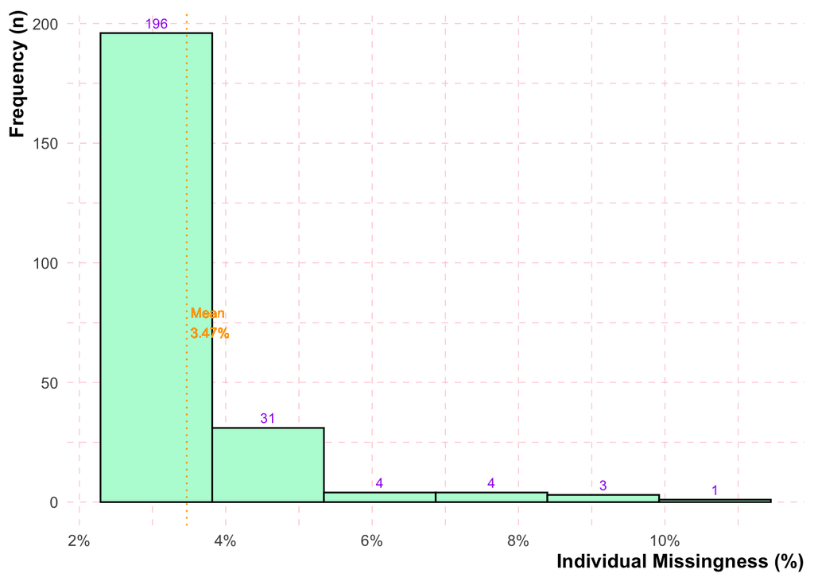

```r
# load plotting theme
source(
  here(
    "scripts", "analysis", "my_theme2.R"
  )
)

ggplot( # Start a ggplot object with the data and aesthetic mappings
  indmiss,
  aes(
    x = F_MISS
  )
) +
  geom_histogram( # Add a histogram layer
    color            = "black",
    fill             = "#B6FAD7",
    bins             = 6
  ) +
  geom_text(
    # Add text labels for bin counts
    stat             = "bin",
    aes(
    label = after_stat(count)
  ),
    vjust            = -0.5,
    color            = "purple",
    size             = 3,
    bins             = 6
  ) +
  geom_vline(
    # Add a vertical line at the mean of F_MISS
    aes(
    xintercept = mean(F_MISS)),
    color            = "orange",
    linetype         = "dotted",
    linewidth        = .5
  ) +
  geom_text(
    # Add a text label for the mean of F_MISS
    aes(
      x = mean(F_MISS),
      y = 75,
      label = paste0(
        "Mean \n",
        scales::percent(mean(F_MISS),
          accuracy = 0.01
        )
      )
    ),
    size = 3,
    color = "orange",
    hjust = -.1
  ) +
  labs( # Add axis labels
    x                = "Individual Missingness (%)",
    y                = "Frequency (n)"
  ) +
  my_theme() +
  scale_x_continuous( # Scale the x-axis to display percentages
    labels           = scales::percent,
    n.breaks         = 6
  )
```

```r
#
# save the plot
ggsave(
  here(
    "output", "populations", "figures" , "individual_missingness.pdf"
  ),
  width              = 7,
  height             = 5,
  units              = "in"
)
```

The function my_theme() that we imported above

```r
# Define a function to customize the theme
my_theme <- function() {
  theme_minimal(base_size = 12, base_family = "") +
    theme(
      panel.grid.major = element_line(
        linetype = "dashed",
        linewidth = 0.2,
        color = "pink"
      ),
      panel.grid.minor = element_line(
        linetype = "dashed",
        linewidth = 0.2,
        color = "pink"
      ),
      # Customize the x-axis label
      axis.title.x = element_text(
        angle          = 0,
        hjust          = 1,
        face           = "bold"
      ),
      # Customize the y-axis label
      axis.title.y = element_text(
        angle          = 90,
        hjust          = 1,
        face           = "bold"
      )
    )
}
# we can save the function to source it later
dump(                                                    # check ?dump for more information
  "my_theme",                                            # the object we want to save
  here(
    "scripts", "analysis", "my_theme2.R")                # use here to save it our function as .R
)
```

Plot variant missingness

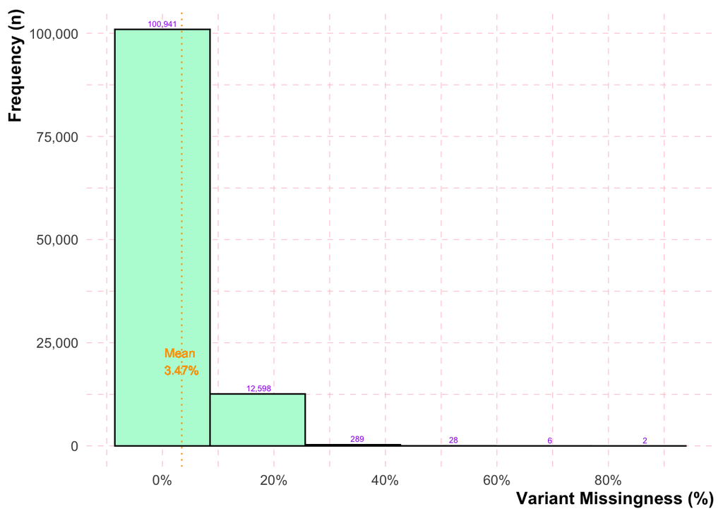

```r
# This plot takes a while to compute
# This code creates a histogram from the indmiss data set using the F_MISS column.
# ggplot builds a histogram of individual missingness data
ggplot(
  snpmiss,
  aes(
    x = F_MISS
  )
) +
  geom_histogram(
    color = "black",
    fill = "#B6FAD7",
    bins = 6
  ) +
  stat_bin(
    geom = "text",
    aes(
      label = format(
        after_stat(count),
        big.mark = ",",
        scientific = FALSE
      )
    ),
    vjust = -0.5,
    color = "purple",
    size = 2,
    bins = 6
  ) +
  geom_vline(
    aes(
      xintercept = mean(F_MISS)
    ),
    color = "orange",
    linetype = "dotted",
    linewidth = 0.5
  ) +
  geom_text(
    aes(
      x = mean(F_MISS),
      y = 16000,
      label = paste0(
        "Mean \n",
        scales::percent(mean(F_MISS),
          accuracy = 0.01
        )
      )
    ),
    size = 3,
    color = "orange",
    # hjust = 1.5,
    vjust = -.2
  ) +
  labs(
    x = "Variant Missingness (%)",
    y = "Frequency (n)"
  ) +
  # theme_minimal(
  #   base_size = 12,
  #   base_family = "Roboto Condensed"
  # ) +
  scale_x_continuous(
    labels = scales::percent,
    n.breaks = 6
  ) +
  scale_y_continuous(
    labels = scales::label_comma(),
    n.breaks = 5
  ) +
  my_theme()
```

```r
# save the plot
ggsave(
  here(
    "output", "populations", "figures", "SNPs_missingness.pdf"
  ),
  width  = 7,
  height = 5,
  units  = "in"
)
```

Remove individuals missing more than 20% of SNPs. You can use the threshold you want, change the flag –mind

```bash
plink2 \
--allow-extra-chr \
--bfile output/populations/file2 \
--mind 0.2               `# here we set the individual missingness threshold of 20%`\
--make-bed \
--out output/populations/file3 \
--silent;
grep "samples\|variants" output/populations/file3.log
```

```
## 239 samples (30 females, 69 males, 140 ambiguous; 239 founders) loaded from
## 104139 variants loaded from output/populations/file2.bim.
## 0 samples removed due to missing genotype data (--mind).
## 239 samples (30 females, 69 males, 140 ambiguous; 239 founders) remaining after
```

## 3.2 Minor allele frequency

First lets make a plot of the MAF. First, we estimate the allele frequency with Plink.

```bash
plink2 \
--allow-extra-chr \
--bfile output/populations/file3 \
--freq \
--out output/populations/MAF_check \
--silent
```

Then we plot it with ggplot.

```r
#   ____________________________________________________________________________
#   Import MAF data                                                         ####
maf_freq <-
  read.delim(
    here(
      "output", "populations", "MAF_check.afreq"
    ),
    header = TRUE
  )
```

Make MAF plot

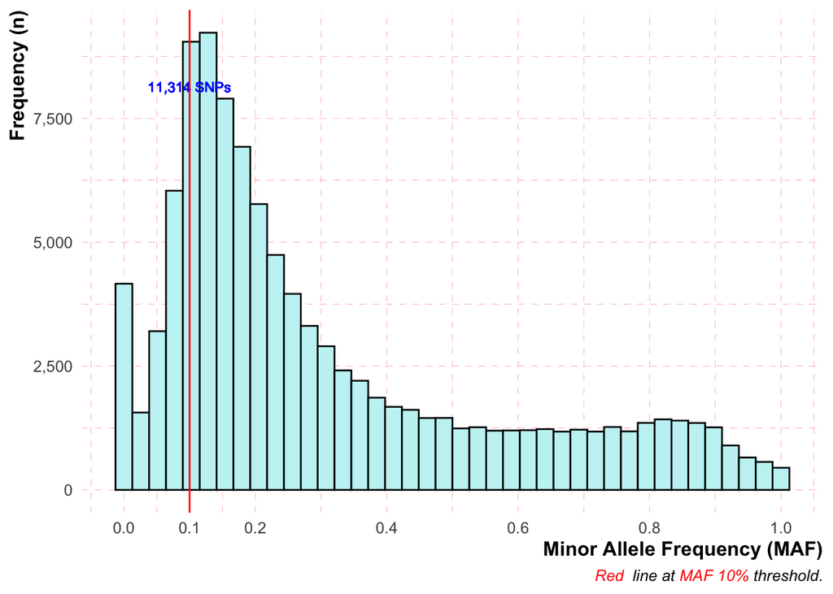

```r
#   ____________________________________________________________________________
#   make the plot                                                           ####
ggplot(
  maf_freq,
  aes(ALT_FREQS)
) +
  geom_histogram(
    colour = "black",
    fill = "#C4F3F5",
    bins = 40
  ) +
  labs(
    x = "Minor Allele Frequency (MAF)",
    y = "Frequency (n)",
    caption = "<span style='color:red;'><i>Red</i></span> <span style='color:black;'><i>line at</i></span><span style='color:red;'><i> MAF 10%</i></span><span style='color:black;'><i> threshold</i></span>."
  ) +
  geom_text(
    aes(
      x = .1,
      y = 8000,
      label = paste0("11,314 SNPs")
    ),
    size = 3,
    color = "blue",
    vjust = -.2
  ) +
  geom_vline(xintercept = 0.1, color = "red") +
  my_theme() +
  theme(plot.caption = element_markdown()) +
  scale_y_continuous(label = scales::number_format(big.mark = ",")) +
  scale_x_continuous(breaks = c(0, 0.1, 0.2, 0.4, 0.6, 0.8, 1))
```

```r
#   ____________________________________________________________________________
#   save the plot                                                           ####
ggsave(
  here(
    "output", "populations", "figures", "MAF.pdf"
  ),
  width  = 5,
  height = 4,
  units  = "in"
)
```

Now we apply the MAF filter.

```bash
# We will use MAF of 10%
plink2 \
--allow-extra-chr \
--bfile output/populations/file3 \
--maf 0.1 \
--make-bed \
--out output/populations/file4 \
--silent;
grep "variants" output/populations/file4.log
```

```bash
mkdir -p output/populations/hardy;
cp output/populations/file4.* output/populations/hardy/
```

## 3.3 HWE test

Now we can run the HWE test. However, we will need to apply the SNP missingness again for each population. If we do not, the HWE will vary widely. With the bash script below, we will create a new file for each population, run the HWE test with HWE p value <1e‐6 (HWE p value <1e‐6). Then, we ask Plink to generate a list of SNPs that passed the test for each population.

```bash
for fam in $(awk '{print $1}' output/populations/hardy/file4.fam | sort | uniq);
do
echo $fam | \
plink2 \
--allow-extra-chr \
--silent \
--keep-allele-order \
--bfile output/populations/hardy/file4 \
--keep-fam /dev/stdin \
--make-bed \
--out output/populations/hardy/$fam \
--hwe 0.000001 \
--geno 0.1 \
--write-snplist; \
done
```

Next, we use “cat” and “`awk`” to concatenate the SNP list from all populations, and remove duplicates. Once we have a list of SNPs that passed the test for each population, we can use Plink to create a new bed file keeping only the SNPs that passed the test in each population. First, lets get the list of SNPs, and count how many passed:

```bash
cat output/populations/hardy/*.snplist | awk '!a[$0]++' > output/populations/passed_hwe.txt;
wc -l output/populations/passed_hwe.txt
```

How many variants we had before

```bash
cat output/populations/file4.bim | awk '{print $2}'| awk '!a[$0]++' | wc -l
```

```
##    82731
```

Variants not passing HWE test

```r
82731 - 82731
```

```
## [1] 0
```

All variants passed HWE test. If some failed, next time we could remove the variants that did not pass HWE test, using the –extract flag, extracting only those that passed HWE.

## 3.4 LD pruning

```bash
plink2 \
--allow-extra-chr \
--bfile output/populations/file4 \
--extract output/populations/passed_hwe.txt \
--indep-pairwise 5 1 0.1 \
--out output/populations/indepSNP \
--silent;
grep 'pairwise\|variants\|samples' output/populations/indepSNP.log
```

```
##   --indep-pairwise 5 1 0.1
## 239 samples (30 females, 69 males, 140 ambiguous; 239 founders) loaded from
## 82731 variants loaded from output/populations/file4.bim.
## --extract: 82731 variants remaining.
## 82731 variants remaining after main filters.
## --indep-pairwise (11 compute threads): 22057/82731 variants removed.
```

Remember, the SNPs are not removed from our data set. Plink created 3 files when we ran the code above. One is the “indepSNP.log” file, and the other two are:  
“**indepSNP.prune.in**” -> list of SNPs with squared correlation smaller than our r2 threshold of 0.1.  
“i**ndepSNP.prune.out**” -> list of SNPs with squared correlation greater than our r2 threshold of 0.1. For our heterozygosity estimates, we want to use the set of SNPs that are below our r2 threshold of 0.1. We consider that they are randomly associated. We can use Plink to estimate the heterozygosity using the “indepSNP.prune.in” file.

## 3.4 Heterozygosity

```bash
plink2 \
--allow-extra-chr \
--bfile output/populations/file4 \
--extract output/populations/indepSNP.prune.in \
--het \
--out output/populations/R_check \
--silent;
grep 'variants' output/populations/R_check.log
```

```
## 82731 variants loaded from output/populations/file4.bim.
## --extract: 60674 variants remaining.
## 60674 variants remaining after main filters.
```

```r
#   ____________________________________________________________________________
#   find individuals with high heterozygosity                              ####
# import the data from Plink
het <- read.delim(
  here(
    "output", "populations", "R_check.het"
  ),
  head = TRUE
)
#
# check head of the file
colnames(het)
```

```
## [1] "X.FID"  "IID"    "O.HOM." "E.HOM." "OBS_CT" "F"
```

Estimate het

```r
# create a column named HET_RATE and calculate the heterozygosity rate
het$HET_RATE <- (het$"OBS_CT" - het$"O.HOM") / het$"OBS_CT"
#
# use subset function to get values deviating from 4sd of the mean heterozygosity rate.
het_fail <-
  subset(
    het, (het$HET_RATE < mean(
      het$HET_RATE
    ) - 4 * sd(
      het$HET_RATE
    )) |
      (het$HET_RATE > mean(
        het$HET_RATE
      ) + 4 * sd(
        het$HET_RATE
      ))
  )
#
# get the list of individuals that failed our threshold of 4sd from the mean.
het_fail$HET_DST <-
  (het_fail$HET_RATE - mean(
    het$HET_RATE
  )) / sd(
    het$HET_RATE
  )
```

Save the files to use with Plink

```r
#   ____________________________________________________________________________
#   save the data to use with Plink2                                        ####
#
write.table(
  het_fail,
  here(
    "output", "populations", "fail-het-qc.txt"
  ),
  row.names = FALSE
)
```

Make plot

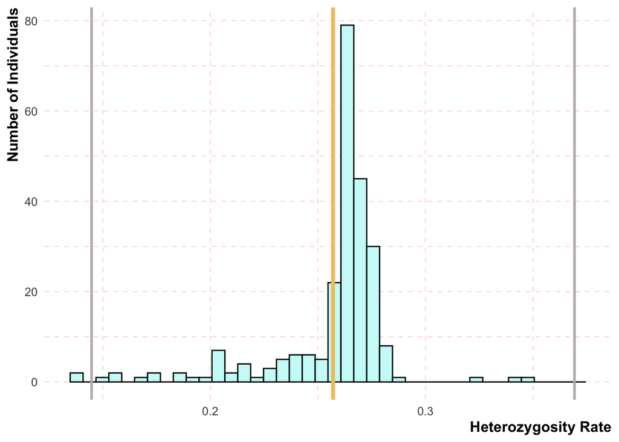

```r
#   ____________________________________________________________________________
#   make a heterozygosity plot                                              ####
#
ggplot(
  het,
  aes(
    HET_RATE
  )
) +
  geom_histogram(
    colour           = "black",
    fill             = "#CDFAF8",
    bins             = 40
  ) +
  labs(
    x                = "Heterozygosity Rate",
    y                = "Number of Individuals"
  ) +
  geom_vline(
    aes(
      xintercept     = mean(
        HET_RATE
      )
    ),
    col              = "#F2C46F",
    linewidth        = 1.5
  ) +
  geom_vline(
    aes(
      xintercept     = mean(
        HET_RATE
      ) + 4 * sd(
        HET_RATE
      )
    ),
    col              = "#BFB9B9",
    linewidth        = 1
  ) +
  geom_vline(
    aes(
      xintercept     = mean(
        HET_RATE
      ) - 4 * sd(
        HET_RATE
      )
    ),
    col              = "#BFB9B9",
    linewidth        = 1
  ) +
  my_theme() +
  scale_y_continuous(
    labels           = comma
  )
```

```r
#   ____________________________________________________________________________
#   save the heterozygosity plot                                            ####
ggsave(
  here(
    "output", "populations", "figures", "Heterozygosity.pdf"
  ),
  width  = 5,
  height = 4,
  units  = "in"
)
```

```bash
sed 's/"// g' output/populations/fail-het-qc.txt | awk '{print$1, $2}'> output/populations/het_fail_ind.txt;
echo 'How many mosquitoes we need to remove from our data set:';
cat output/populations/het_fail_ind.txt | tail -n +2 | wc -l;
echo 'Which mosquitoes we have to remove:';
tail -n +2 output/populations/het_fail_ind.txt
```

```
## How many mosquitoes we need to remove from our data set:
##        2
## Which mosquitoes we have to remove:
## KAT 9
## KAT 12
```

Next, we will remove these mosquitoes from our data set using Plink:

```bash
plink2 \
--allow-extra-chr \
--bfile output/populations/file4 \
--remove output/populations/het_fail_ind.txt \
--make-bed \
--out output/populations/file5 \
--silent;
grep 'variants\|samples' output/populations/file5.log
```

## 3.6 Relatedness

Check for cryptic relatedness. Check Plink2 documentation https://www.cog-genomics.org/plink/2.0/distance You can download King directly https://www.kingrelatedness.com/manual.shtml or check their manuscript https://www.ncbi.nlm.populations.gov/pmc/articles/PMC3025716/pdf/btq559.pdf From Plink2 documentation: “Note that KING kinship coefficients are scaled such that duplicate samples have kinship 0.5, not 1. First-degree relations (parent-child, full siblings) correspond to ~0.25, second-degree relations correspond to ~0.125, etc. It is conventional to use a cutoff of ~0.354 (the geometric mean of 0.5 and 0.25) to screen for monozygotic twins and duplicate samples, ~0.177 to add first-degree relations, etc.” There two options. One is to run only –make-king and another one is to use –make-king-table We will use the threshold of 0.354 and create a table.

```bash
# Plink2 will create a file with extension .king
plink2 \
--allow-extra-chr \
--bfile output/populations/file4 \
--extract output/populations/indepSNP.prune.in \
--make-king-table rel-check \
--king-table-filter 0.354 \
--out output/populations/file5 \
--silent;
grep 'variants\|samples' output/populations/file5.log
```

```
## 239 samples (30 females, 69 males, 140 ambiguous; 239 founders) loaded from
## 82731 variants loaded from output/populations/file4.bim.
## --extract: 60674 variants remaining.
## 60674 variants remaining after main filters.
```

Check the individuals that did not pass our filtering.

```bash
head output/populations/file5.kin0
```

```
## #FID1    IID1    FID2    IID2    NSNP    HETHET  IBS0    KINSHIP
## KAN  1327    KAN 1325    58810   0.226679    0.00851896  0.400443
## OKI  1010    OKI 1006    57912   0.219903    0.0134687   0.356474
```

We want to remove one of the individuals of the pairs.

```bash
plink2 \
--allow-extra-chr \
--bfile output/populations/file4 \
--extract output/populations/indepSNP.prune.in \
--make-king triangle bin \
--out output/populations/file6 \
--silent;
grep 'variants\|samples' output/populations/file6.log
```

```
## 239 samples (30 females, 69 males, 140 ambiguous; 239 founders) loaded from
## 82731 variants loaded from output/populations/file4.bim.
## --extract: 60674 variants remaining.
## 60674 variants remaining after main filters.
## --make-king pass 1/1: Scanning for rare variants... done.
## 0 variants handled by initial scan (60674 remaining).
## --make-king: 60674 variants processed.
```

Now we can use Plink2 to remove one of the mosquitoes from the pair with high kinship. It will remove 2 samples since we had 2 samples in some populations with high relatedness, and we could remove 1 and keep the other two. Plink2 always tries to maximize the number of samples passing the filters.

```bash
plink2 \
--allow-extra-chr \
--bfile output/populations/file4 \
--king-cutoff output/populations/file6 0.354 \
--make-bed \
--out output/populations/file7 \
--silent;
grep 'samples\|variants\|remaining' output/populations/file7.log
```

```
## 239 samples (30 females, 69 males, 140 ambiguous; 239 founders) loaded from
## 82731 variants loaded from output/populations/file4.bim.
## output/populations/file7.king.cutoff.out.id , and 237 remaining sample IDs
```

Now we can check the individuals that were removed.

```bash
head -n 10 output/populations/file7.king.cutoff.out.id
```

```
## #FID IID
## OKI  1010
## KAN  1327
```